# IODS course project

Ilhan Cem Duru

# About the project

### Data Science course

Thank you for this **online** course. Everybody should learn about *data science*.  
This project is all about learning data science.  
Without a good interpretation and analysis the raw data cannot tell the valuable information.  
With this couse we will learn how to analyze the data efficiently.  
Please find my couse github page with this link: [my course page link](https://github.com/icemduru/IODS-project)

#### Thanks.

Note: *English is not my native language, you can see some grammatical mistakes in this page.*

# Analysis

*Lots of regression analysis in this week…*

### Preliminary review of the data

Let’s get the data. if you want to know more about the data, please read the manual webpage about it with this [link](http://www.helsinki.fi/~kvehkala/JYTmooc/JYTOPKYS3-meta.txt)

```r
our_data = read.table("/home/iduru/Desktop/IODS-project/learning2014.txt", sep = ",", header = TRUE)
#checking the dimentions of the data
dim(our_data)
```

```
## [1] 166   7
```

```r
#our data has 166 row and 7 columns

#checking the structure of the data
str(our_data)
```

```
## 'data.frame':    166 obs. of  7 variables:
##  $ gender  : Factor w/ 2 levels "F","M": 1 2 1 2 2 1 2 1 2 1 ...
##  $ Age     : int  53 55 49 53 49 38 50 37 37 42 ...
##  $ attitude: num  3.7 3.1 2.5 3.5 3.7 3.8 3.5 2.9 3.8 2.1 ...
##  $ deep    : num  3.58 2.92 3.5 3.5 3.67 ...
##  $ stra    : num  3.38 2.75 3.62 3.12 3.62 ...
##  $ surf    : num  2.58 3.17 2.25 2.25 2.83 ...
##  $ Points  : int  25 12 24 10 22 21 21 31 24 26 ...
```

We can see the variable names and values of each samples. 7 total variable and 166 samples are there.

### Creating the graphical overview of the data

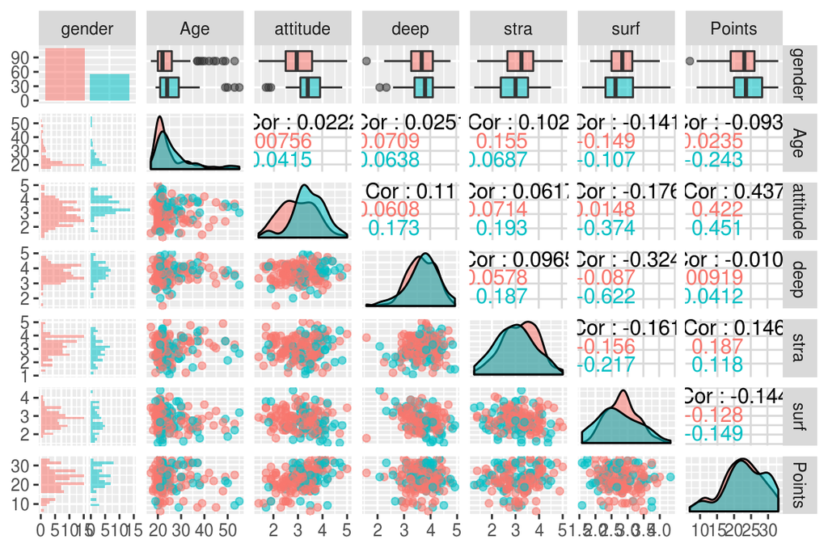

```r
#we will create graphical overview of the data, we need library. so we are calling libraries.

library(ggplot2)
library(GGally)
# graphical overview creting codes.
p <- ggpairs(our_data, mapping = aes(col=gender,alpha = 0.3), lower = list(combo = wrap("facethist", bins = 20)))
p
```

Here we can see correlation of each variables.

### Simple regression analysis. (target is Points)

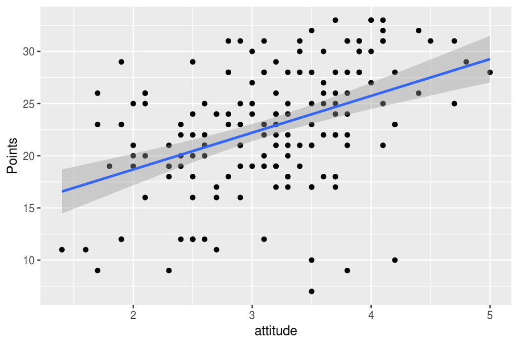

```r
qplot(attitude, Points, data = our_data) + geom_smooth(method = "lm")
```

```r
my_model <- lm(Points ~ attitude, data = our_data)
summary(my_model)
```

```
##
## Call:
## lm(formula = Points ~ attitude, data = our_data)
##
## Residuals:
##      Min       1Q   Median       3Q      Max
## -16.9763  -3.2119   0.4339   4.1534  10.6645
##
## Coefficients:
##             Estimate Std. Error t value Pr(>|t|)
## (Intercept)  11.6372     1.8303   6.358 1.95e-09 ***
## attitude      3.5255     0.5674   6.214 4.12e-09 ***
## ---
## Signif. codes:  0 '***' 0.001 '**' 0.01 '*' 0.05 '.' 0.1 ' ' 1
##
## Residual standard error: 5.32 on 164 degrees of freedom
## Multiple R-squared:  0.1906, Adjusted R-squared:  0.1856
## F-statistic: 38.61 on 1 and 164 DF,  p-value: 4.119e-09
```

Here we created a simple regression analysis for the Points and attitude.  
Our formula is Points ~ attitude, we are interested in regression between points and attitude.  
We can see that the slope value calculated as ~3.5 and as we can see in the summary the statistical significance is very high. (t-value)

### Multiple regression analysis. (target is Points)

```r
my_model2 <- lm(Points ~ attitude + stra+ surf, data = our_data)
summary(my_model2)
```

```
##
## Call:
## lm(formula = Points ~ attitude + stra + surf, data = our_data)
##
## Residuals:
##      Min       1Q   Median       3Q      Max
## -17.1550  -3.4346   0.5156   3.6401  10.8952
##
## Coefficients:
##             Estimate Std. Error t value Pr(>|t|)
## (Intercept)  11.0171     3.6837   2.991  0.00322 **
## attitude      3.3952     0.5741   5.913 1.93e-08 ***
## stra          0.8531     0.5416   1.575  0.11716
## surf         -0.5861     0.8014  -0.731  0.46563
## ---
## Signif. codes:  0 '***' 0.001 '**' 0.01 '*' 0.05 '.' 0.1 ' ' 1
##
## Residual standard error: 5.296 on 162 degrees of freedom
## Multiple R-squared:  0.2074, Adjusted R-squared:  0.1927
## F-statistic: 14.13 on 3 and 162 DF,  p-value: 3.156e-08
```

### Multiple regression analysis version 2

```r
my_model2 <- lm(Points ~ attitude + stra, data = our_data)
summary(my_model2)
```

```
##
## Call:
## lm(formula = Points ~ attitude + stra, data = our_data)
##
## Residuals:
##      Min       1Q   Median       3Q      Max
## -17.6436  -3.3113   0.5575   3.7928  10.9295
##
## Coefficients:
##             Estimate Std. Error t value Pr(>|t|)
## (Intercept)   8.9729     2.3959   3.745  0.00025 ***
## attitude      3.4658     0.5652   6.132 6.31e-09 ***
## stra          0.9137     0.5345   1.709  0.08927 .
## ---
## Signif. codes:  0 '***' 0.001 '**' 0.01 '*' 0.05 '.' 0.1 ' ' 1
##
## Residual standard error: 5.289 on 163 degrees of freedom
## Multiple R-squared:  0.2048, Adjusted R-squared:  0.1951
## F-statistic: 20.99 on 2 and 163 DF,  p-value: 7.734e-09
```

Here we made a multiple regression analysis using Points as a target and attitude and stra as variables.  
We can see that intercept slope is statistically significant while stra slope value is not significantly significant.  
R-squared value is some kind of a metric for evaluating the goodness of fit of the model. 1 is the highest score for the R-squared value.  
R-squared value can be useful for estimating of the strength of the relationship between the model and the variable(s). However, it does not show statistical significance.

### Diagnostic plots

3 different diagnostic plots will be created.

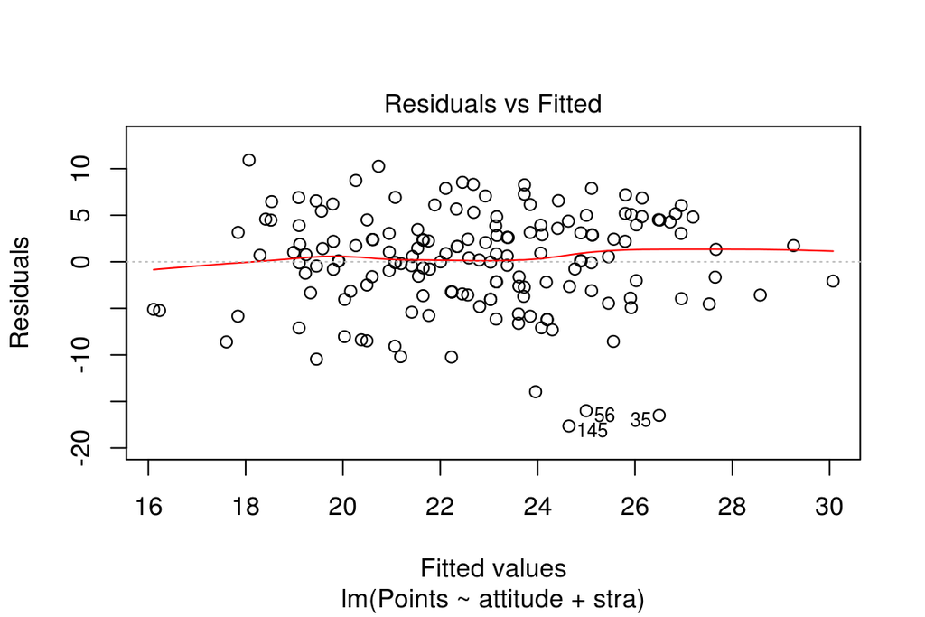

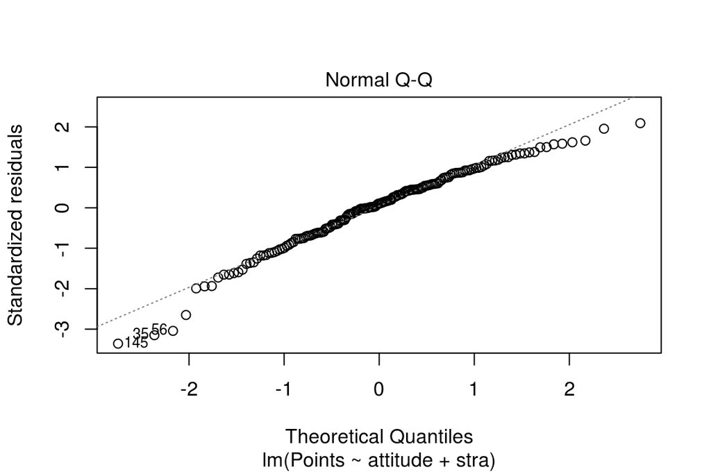

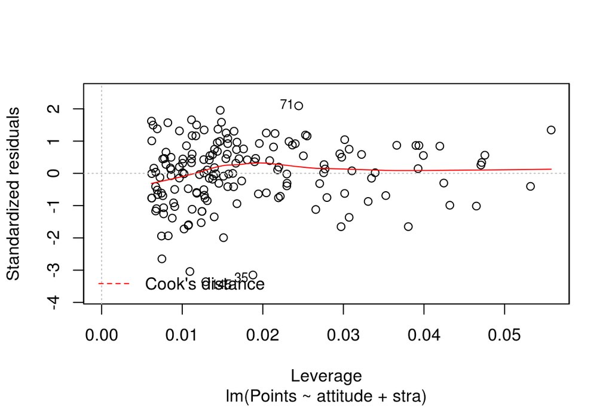

```r
plot(my_model2, which = c(1,2,5),
     caption = list("Residuals vs Fitted", "Normal Q-Q", "Residuals vs Leverage"))
```

1-Residuals vs Fitted, comparing resudual vs model predictions for constant variance of errors. In our case it looks reasonable.  
2-Normal Q-Q plot is testing normality of the errors. In our case normality looks reasonable. We expect that errors are normally distributed.